# Kuo_ChihYu_A1

## A1: Linear Modeling Case Study

Chih-Yu Kuo  
Hult International Business School  
Master of Business Analytics (2023-2024) - San Francisco

#### DAT-5390 | Computational Data Analytics with Python

Chase Kusterer - Faculty of Analytics  
Professor Chase Kusterer

February 28th, 2024

## Analysis Introduction

In this analysis, we embark on a journey through machine learning to solve a predictive modeling problem. I start by preparing data, ensuring it's clean and ready for exploration. Then, I dive into exploring the data, seeking patterns and relationships to better understand it. Afterward, I proceed to build and fine-tune a decision tree model, leveraging my insights to enhance its accuracy. Finally, I use this model to predict outcomes on new data and submit the results. Overall, my goal is not only to excel in the challenge but also to demonstrate how a structured data science approach can effectively address complex problems.

## Exploratory Data Analysis and Data Preprocessing

In the analysis, I start with Exploratory Data Analysis, using visual tools to detect outliers and scrutinize variable distributions. I also identify missing values. I address them with appropriate imputation. Next, I split the dataset into training and testing sets, which is crucial for evaluating the model's performance on unseen data. This phase yields critical insights that guide preprocessing strategies. I then apply feature engineering techniques to create new features. This enhancing the model's predictive accuracy. By preparing the data through these steps, I establish a solid foundation for the modeling phase. This ensures dataset is optimized for machine learning algorithms. This preparation is essential for achieving accurate and reliable results in predictive modeling.

## Part I: Imports and Data Check

```python
## importing libraries ##

# for this template
import seaborn as sns
import matplotlib.pyplot as plt
import numpy             as np                       # mathematical essentials
import pandas            as pd                       # data science essentials
import sklearn.linear_model                          # linear models
from sklearn.model_selection import train_test_split # train/test split
from sklearn.preprocessing import StandardScaler


#!###############################!#
#!# import additional libraries #!#
#!###############################!#
# import whatever you need


# setting pandas print options (optional)
pd.set_option('display.max_rows', 500)
pd.set_option('display.max_columns', 500)
pd.set_option('display.width', 1000)
```

```python
## importing data ##

# reading modeling data into Python
modeling_data = './train.xlsx'

# calling this df_train
df_train = pd.read_excel(io= modeling_data,
                         sheet_name = 'data',
                         header     = 0,
                         index_col  = 'ID')



# reading testing data into Python
testing_data = './test.xlsx'

# calling this df_test
df_test = pd.read_excel(io= testing_data,
                        sheet_name = 'data',
                        header     = 0,
                        index_col  = 'ID')
```

```python
# concatenating datasets together for my analysis and feature engineering
df_train['set'] = 'Not Kaggle'
df_test ['set'] = 'Kaggle'

# concatenating both datasets together for mv and feature engineering
df_full = pd.concat(objs = [df_train, df_test],
                    axis = 0,
                    ignore_index = False)


# checking data
df_full.head(n = 5)
```

| ID | DateHour | Temperature(F) | Humidity(%) | Wind speed (mph) | Visibility(miles) | DewPointTemperature(F) | Rainfall(in) | Snowfall(in) | SolarRadiation(MJ/m2) | Holiday | FunctioningDay | RENTALS | set |
| --- | --- | --- | --- | --- | --- | --- | --- | --- | --- | --- | --- | --- | --- |
| mb_1039 | 2023-10-14 05:59:54.810000 | 52 | 81 | 0.4 | 2.9 | 46.4 | 0.0 | 0.0 | 0.00 | No | Yes | 519.0 | Not Kaggle |
| mb_1330 | 2023-10-26 08:59:53.355000 | 51 | 53 | 2.2 | NaN | 35.2 | 0.0 | 0.0 | 1.01 | No | Yes | 1251.0 | Not Kaggle |
| mb_551 | 2023-09-23 21:59:57.250000 | 56 | 49 | 2.5 | 3.4 | 38.8 | 0.0 | 0.0 | 0.00 | No | Yes | 1685.0 | Not Kaggle |
| mb_2103 | 2023-12-19 14:00:00 | 69 | 32 | 9.8 | 12.4 | 38.7 | 0.0 | 0.0 | 2.36 | No | No | 0.0 | Not Kaggle |
| mb_1430 | 2023-10-30 12:59:52.855000 | 53 | 20 | 2.9 | 10.8 | 12.9 | 0.0 | 0.0 | 1.96 | No | Yes | 814.0 | Not Kaggle |

```python
# checking available features
df_full.columns
```

```
Index(['DateHour', 'Temperature(F)', 'Humidity(%)', 'Wind speed (mph)', 'Visibility(miles)', 'DewPointTemperature(F)', 'Rainfall(in)', 'Snowfall(in)', 'SolarRadiation(MJ/m2)', 'Holiday', 'FunctioningDay', 'RENTALS', 'set'], dtype='object')
```

```python
# descriptive statistics
df_full.describe()
```

|  | Temperature(F) | Humidity(%) | Wind speed (mph) | Visibility(miles) | DewPointTemperature(F) | Rainfall(in) | Snowfall(in) | SolarRadiation(MJ/m2) | RENTALS |
| --- | --- | --- | --- | --- | --- | --- | --- | --- | --- |
| count | 2184.000000 | 2184.000000 | 2184.000000 | 2108.000000 | 2117.000000 | 2184.000000 | 2184.000000 | 2078.000000 | 1638.000000 |
| mean | 57.389652 | 59.228480 | 3.344780 | 9.646964 | 42.036089 | 0.004858 | 0.002015 | 0.547161 | 828.153846 |
| std | 12.861669 | 18.686445 | 2.071144 | 3.492413 | 13.997667 | 0.037354 | 0.018550 | 0.810564 | 657.599846 |
| min | 26.000000 | 13.000000 | 0.000000 | 0.000000 | -2.200000 | 0.000000 | 0.000000 | 0.000000 | 0.000000 |
| 25% | 48.000000 | 44.000000 | 1.800000 | 7.400000 | 33.400000 | 0.000000 | 0.000000 | 0.000000 | 241.500000 |
| 50% | 57.000000 | 59.000000 | 2.900000 | 11.700000 | 41.900000 | 0.000000 | 0.000000 | 0.000000 | 761.500000 |
| 75% | 68.000000 | 74.000000 | 4.500000 | 12.400000 | 51.600000 | 0.000000 | 0.000000 | 0.980000 | 1203.750000 |
| max | 91.000000 | 97.000000 | 12.800000 | 12.400000 | 75.000000 | 0.710000 | 0.300000 | 3.180000 | 3303.000000 |

```python
#!##############################!#
#!# set your response variable #!#
#!##############################!#
y_variable ='RENTALS'
```

## Exploratory Data Analysis

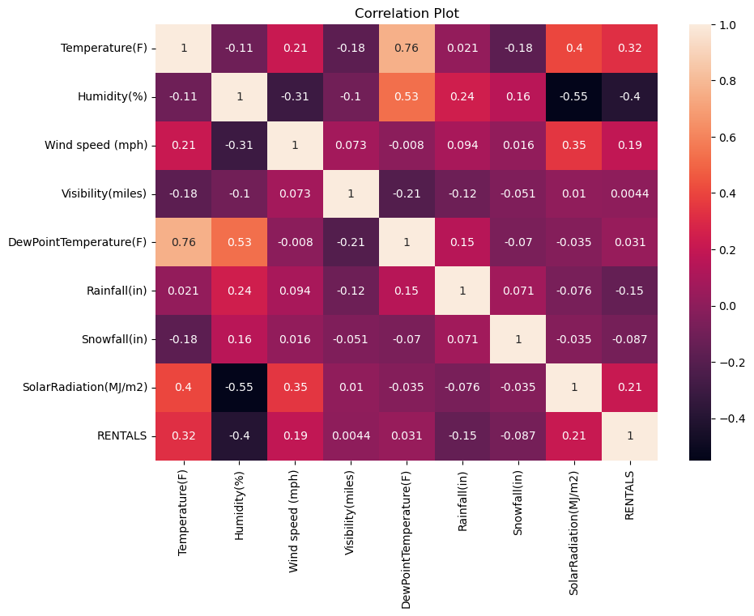

```python
# Correlation plot to check the association between the variables

# Set the figure size for the plot
plt.figure(figsize=(10,7))

# Generate a heatmap to visualize the correlation matrix of the DataFrame
# 'annot=True' displays the correlation values on the heatmap
sns.heatmap(df_full.corr(),
            annot=True)

# Add a title to the plot
plt.title('Correlation Plot')

# Show the plot
plt.show()
```

- Strong positive correlation between Temperature and Dew Point Temperature.
- Moderate positive correlation between Humidity and Dew Point Temperature.
- Negative correlation between Humidity and Solar Radiation, suggesting lower solar radiation with higher humidity.
- Positive correlation between Temperature and Solar Radiation.
- Rentals show a modest positive correlation with Temperature and negative correlation with Humidity.
- Wind Speed has no strong correlation with other variables.

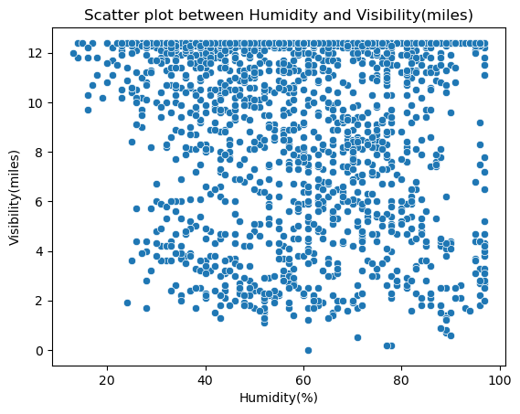

```python
# Generate a scatter plot to visualize the relationship between Humidity (%) and Visibility (miles)
sns.scatterplot(data=df_full,
                x="Humidity(%)",
                y="Visibility(miles)")

# Add a title to the plot
plt.title('Scatter plot between Humidity and Visibility(miles)')

# Show the plot
plt.show()
```

The plot above is a scatter plot showing the relationship between Humidity and Visibility (miles). From the plot, it is observed that the data points are widely dispersed across the graph without any clear pattern or trend suggesting a strong linear relationship. This implies that there is no direct correlation between these two features where an increase or decrease in humidity could be used to predict a corresponding change in visibility. Moreover, at higher humidity levels, the visibility seems to vary widely, from very low to high. It suggests that other environmental factors, such as temperature or particulate matter, play a role in determining visibility, along with humidity.

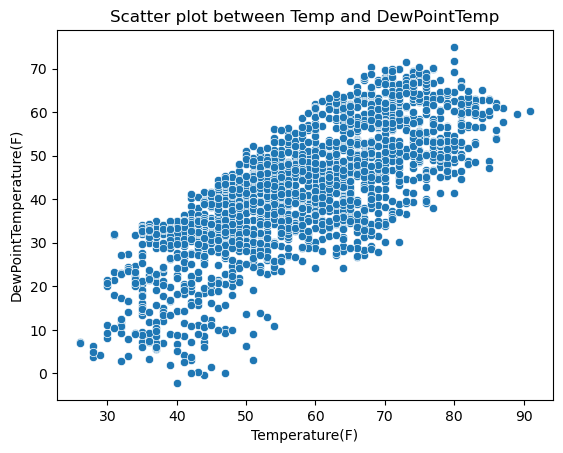

```python
# Generate a scatter plot to visualize the relationship between Temperature (F) and Dew Point Temperature (F)
sns.scatterplot(data = df_full,
                x="Temperature(F)",
                y="DewPointTemperature(F)")

# Add a title to the plot
plt.title ('Scatter plot between Temp and DewPointTemp')

# Show the plot
plt.show()
```

The plot above is a Scatter plot showing the relationship between Temperature and Dewpoint temperature. The plot shows that some level of multi-colinearity exists between these two features. It shows a distinct positive trend, indicating that as the temperature increases, the dew point temperature also tends to increase. The relationship appears non-linear, with a steeper gradient at lower temperatures that levels off as the temperature increases. The density of the data points is greater in the middle of the temperature range, suggesting that most of the observations fall within a more moderate temperature range.

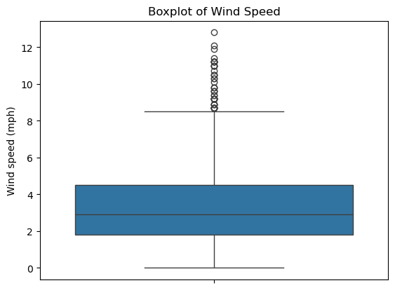

```python
# Generate a boxplot to visualize the distribution of Wind Speed (mph)
sns.boxplot(y = df_full["Wind speed (mph)"])

# Add a title to the plot
plt.title('Boxplot of Wind Speed')

# Show the plot
plt.show()
```

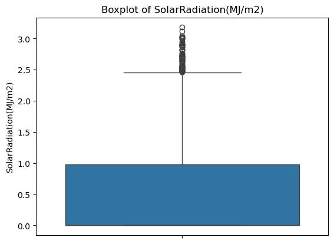

```python
# Generate a boxplot to visualize the distribution of Solar Radiation (MJ/m2)
sns.boxplot(y = df_full["SolarRadiation(MJ/m2)"])

# Add a title to the plot
plt.title("Boxplot of SolarRadiation(MJ/m2)")

# Show the plot
plt.show()
```

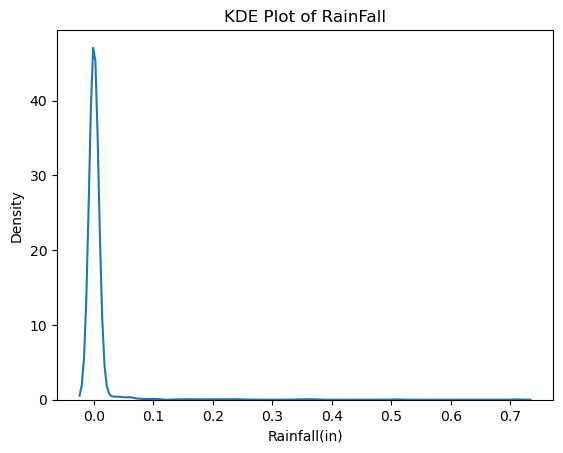

```python
# Generate a KDE plot to visualize the distribution of Rainfall (inches)
sns.kdeplot(data = df_full,
            x="Rainfall(in)")

# Add a title to the plot
plt.title('KDE Plot of RainFall')

# Show the plot
plt.show()
```

The plot above is the KDE plot for the rainfall feature, the plot shows that a lot of the rainfall value in the dataset is 0. The sharp peak at or near 0 indicates that there are many occurrences of no rainfall in the dataset, which suggests a dry climate or the recording of data over a period with many dry days. The plot is heavily skewed to the right, which means there are relatively few instances of higher rainfall amounts compared to the frequency of no or low rainfall. The long tail to the right suggests that while most of the time there is little to no rain, occasionally there can be days with more significant rainfall amounts. The plot doesn't show a clear peak for small amounts of rainfall. This suggests that when it rains, it's more likely to be a measurable amount rather than just a light drizzle.

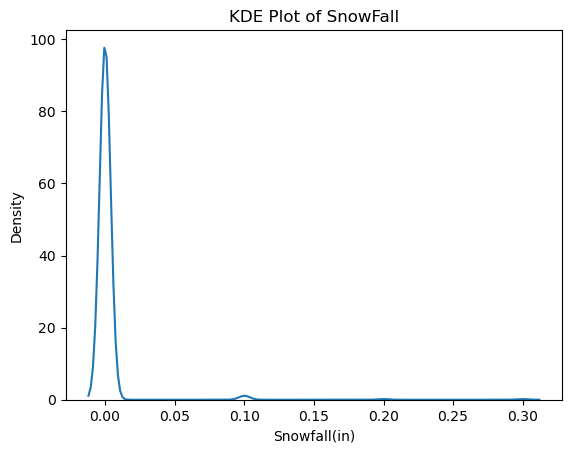

```python
# Generate a KDE plot to visualize the distribution of Snowfall (inches)
sns.kdeplot(data=df_full,
            x="Snowfall(in)")

# Add a title to the plot
plt.title('KDE Plot of SnowFall')

# Show the plot
plt.show()
```

The plot above is the KDE plot for the Snowfall feature, the plot shows that a lot of the Snowfall value in the dataset is 0. The plot is right-skewed, with a long tail extending towards higher values of snowfall. This indicates that snowfall events are generally infrequent but can occur with varying intensities. The density drops off rapidly as snowfall increases, which suggests that significant snowfall is rare. The high density values near 0 imply that the dataset likely spans a period with many days without snow or that it comes from a geographic area where snow is not common.

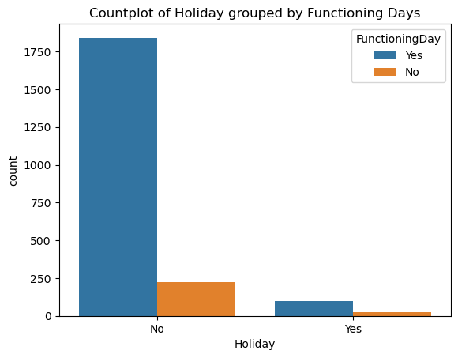

```python
# Generate a countplot to visualize the number of holidays grouped by Functioning Days
sns.countplot(x = "Holiday",
              hue = "FunctioningDay",
              data = df_full)

# Add a title to the plot
plt.title('Countplot of Holiday grouped by Functioning Days')

# Show the plot
plt.show()
```

## Part II: Data Preparation

Complete the following steps to prepare for model building. Note that you may add or remove steps as you see fit. Please see the assignment description for details on what steps are required for this project.

### Base Modeling

```python
import statsmodels.api as sm
import statsmodels.formula.api as smf

# Define the formula for the regression model
formula = "Q('RENTALS') ~ Q('Temperature(F)') + Q('Humidity(%)') + Q('Wind speed (mph)') + Q('Visibility(miles)') + Q('DewPointTemperature(F)') + Q('Rainfall(in)') + Q('Snowfall(in)') + Q('SolarRadiation(MJ/m2)') + Q('Holiday') + Q('FunctioningDay')"

# Create the model
lm_best = smf.ols(formula=formula, data=df_full)

# Fit the model
results = lm_best.fit()

# Print the summary of the regression
print(results.summary())
```

```
                            OLS Regression Results
==============================================================================
Dep. Variable:           Q('RENTALS')   R-squared:                       0.487
Model:                            OLS   Adj. R-squared:                  0.483
Method:                 Least Squares   F-statistic:                     137.0
Date:                Wed, 28 Feb 2024   Prob (F-statistic):          3.40e-201
Time:                        23:37:04   Log-Likelihood:                -11028.
No. Observations:                1456   AIC:                         2.208e+04
Df Residuals:                    1445   BIC:                         2.214e+04
Df Model:                          10
Covariance Type:            nonrobust
===============================================================================================
                                  coef    std err          t      P>|t|      [0.025      0.975]
-----------------------------------------------------------------------------------------------
Intercept                     242.6657    220.072      1.103      0.270    -189.030     674.361
Q('Holiday')[T.Yes]          -164.0011     58.756     -2.791      0.005    -279.257     -48.745
Q('FunctioningDay')[T.Yes]   1023.3447     41.281     24.790      0.000     942.367    1104.322
Q('Temperature(F)')             3.9172      4.888      0.801      0.423      -5.671      13.506
Q('Humidity(%)')              -23.6576      2.601     -9.097      0.000     -28.759     -18.556
Q('Wind speed (mph)')          19.1254      6.552      2.919      0.004       6.274      31.977
Q('Visibility(miles)')          8.4349      3.709      2.274      0.023       1.160      15.710
Q('DewPointTemperature(F)')    19.3412      5.214      3.710      0.000       9.114      29.568
Q('Rainfall(in)')            -796.3970    371.688     -2.143      0.032   -1525.503     -67.291
Q('Snowfall(in)')            1075.4801    782.949      1.374      0.170    -460.358    2611.318
Q('SolarRadiation(MJ/m2)')   -168.1954     20.639     -8.149      0.000    -208.682    -127.709
==============================================================================
Omnibus:                      163.426   Durbin-Watson:                   2.056
Prob(Omnibus):                  0.000   Jarque-Bera (JB):              243.256
Skew:                           0.814   Prob(JB):                     1.50e-53
Kurtosis:                       4.165   Cond. No.                     6.00e+03
==============================================================================

Notes:
[1] Standard Errors assume that the covariance matrix of the errors is correctly specified.
[2] The condition number is large,  6e+03. This might indicate that there are
strong multicollinearity or other numerical problems.
```

### Missing Value Analysis and Imputation

```python
# Check for missing values
df_full.isna().sum()
```

```
DateHour                    0
Temperature(F)              0
Humidity(%)                 0
Wind speed (mph)            0
Visibility(miles)          76
DewPointTemperature(F)     67
Rainfall(in)                0
Snowfall(in)                0
SolarRadiation(MJ/m2)     106
Holiday                     0
FunctioningDay              0
RENTALS                   546
set                         0
dtype: int64
```

```python
## Missing Value Imputation with Ffill ##
df_full.ffill(inplace=True)
```

```python
# Check for missing values again
df_full.isna().sum()
```

```
DateHour                  0
Temperature(F)            0
Humidity(%)               0
Wind speed (mph)          0
Visibility(miles)         0
DewPointTemperature(F)    0
Rainfall(in)              0
Snowfall(in)              0
SolarRadiation(MJ/m2)     0
Holiday                   0
FunctioningDay            0
RENTALS                   0
set                       0
dtype: int64
```